# Retail Sales Forecasting

Michelle Kituku

# Retail Sales Forecasting with ARIMA & SARIMA

## Load Libraries

```r
library(tidyverse)
library(lubridate)
library(forecast)
```

```r
library(ggplot2)
```

## Load and clean 2023 data

```r
data_2023 <- read.csv("retail_sales.csv", stringsAsFactors = FALSE)

# Rename columns to remove spaces
colnames(data_2023) <- c("TransactionID", "Date", "CustomerID", "Gender", "Age",
                         "ProductCategory", "Quantity", "PricePerUnit", "TotalAmount")

# Convert Date to Date type
data_2023$Date <- as.Date(data_2023$Date)  # YYYY-MM-DD format works directly

# Ensure other columns are correct type
data_2023$Gender <- as.character(data_2023$Gender)
data_2023$ProductCategory <- as.character(data_2023$ProductCategory)
data_2023$Age <- as.numeric(data_2023$Age)
data_2023$Quantity <- as.numeric(data_2023$Quantity)
data_2023$PricePerUnit <- as.numeric(data_2023$PricePerUnit)
data_2023$TotalAmount <- as.numeric(data_2023$TotalAmount)
```

## Generate Synthetic 2024 data based on the 2023 data

```r
set.seed(123)  # reproducibility
n_2024 <- 1000

data_2024 <- data.frame(
  TransactionID = 1001:(1000 + n_2024),
  Date = sample(seq(as.Date("2024-01-01"), as.Date("2024-12-31"), by="day"),
                n_2024, replace = TRUE),
  CustomerID = paste0("CUST", sprintf("%03d", sample(1:2000, n_2024, replace=TRUE))),
  Gender = sample(data_2023$Gender, n_2024, replace=TRUE),
  Age = sample(data_2023$Age, n_2024, replace=TRUE),
  ProductCategory = sample(data_2023$ProductCategory, n_2024, replace=TRUE),
  Quantity = sample(data_2023$Quantity, n_2024, replace=TRUE),
  PricePerUnit = sample(data_2023$PricePerUnit, n_2024, replace=TRUE)
)

# Compute TotalAmount
data_2024$TotalAmount <- data_2024$Quantity * data_2024$PricePerUnit

# Ensure types match 2023
data_2024$Date <- as.Date(data_2024$Date)
data_2024$Gender <- as.character(data_2024$Gender)
data_2024$ProductCategory <- as.character(data_2024$ProductCategory)
data_2024$Age <- as.numeric(data_2024$Age)
data_2024$Quantity <- as.numeric(data_2024$Quantity)
data_2024$PricePerUnit <- as.numeric(data_2024$PricePerUnit)
data_2024$TotalAmount <- as.numeric(data_2024$TotalAmount)
```

Creates a synthetic dataset for 2024 with randomly sampled customer info and sales values, following the 2023 distributions.

TotalAmount is computed as Quantity * PricePerUnit

## Combine 2023 data with generated 2024 data

```r
combined_data <- rbind(data_2023, data_2024)

# Optional: sort by TransactionID
combined_data <- combined_data %>% arrange(TransactionID)

# Check combined data
dim(combined_data)  # should be 2000 x 9
```

```
## [1] 2000    9
```

```r
head(combined_data)
```

```
##   TransactionID       Date CustomerID Gender Age ProductCategory Quantity
## 1             1 2023-11-24    CUST001   Male  34          Beauty        3
## 2             2 2023-02-27    CUST002 Female  26        Clothing        2
## 3             3 2023-01-13    CUST003   Male  50     Electronics        1
## 4             4 2023-05-21    CUST004   Male  37        Clothing        1
## 5             5 2023-05-06    CUST005   Male  30          Beauty        2
## 6             6 2023-04-25    CUST006 Female  45          Beauty        1
##   PricePerUnit TotalAmount
## 1           50         150
## 2          500        1000
## 3           30          30
## 4          500         500
## 5           50         100
## 6           30          30
```

```r
tail(combined_data)
```

```
##      TransactionID       Date CustomerID Gender Age ProductCategory Quantity
## 1995          1995 2024-01-16   CUST1367 Female  54     Electronics        3
## 1996          1996 2024-06-17    CUST779   Male  26     Electronics        2
## 1997          1997 2024-08-27   CUST1584 Female  35        Clothing        1
## 1998          1998 2024-01-09    CUST281   Male  20        Clothing        2
## 1999          1999 2024-10-19   CUST1162 Female  36        Clothing        4
## 2000          2000 2024-11-05   CUST1506 Female  54        Clothing        3
##      PricePerUnit TotalAmount
## 1995          300         900
## 1996           25          50
## 1997           50          50
## 1998          500        1000
## 1999           50         200
## 2000           30          90
```

```r
summary(combined_data)
```

```
##  TransactionID         Date             CustomerID           Gender
##  Min.   :   1.0   Min.   :2023-01-01   Length:2000        Length:2000
##  1st Qu.: 500.8   1st Qu.:2023-06-29   Class :character   Class :character
##  Median :1000.5   Median :2024-01-01   Mode  :character   Mode  :character
##  Mean   :1000.5   Mean   :2023-12-30
##  3rd Qu.:1500.2   3rd Qu.:2024-06-25
##  Max.   :2000.0   Max.   :2024-12-31
##       Age        ProductCategory       Quantity      PricePerUnit
##  Min.   :18.00   Length:2000        Min.   :1.000   Min.   : 25.0
##  1st Qu.:30.00   Class :character   1st Qu.:2.000   1st Qu.: 30.0
##  Median :42.00   Mode  :character   Median :3.000   Median : 50.0
##  Mean   :41.54                      Mean   :2.524   Mean   :177.3
##  3rd Qu.:53.00                      3rd Qu.:4.000   3rd Qu.:300.0
##  Max.   :64.00                      Max.   :4.000   Max.   :500.0
##   TotalAmount
##  Min.   :  25.0
##  1st Qu.:  60.0
##  Median : 120.0
##  Mean   : 453.4
##  3rd Qu.: 900.0
##  Max.   :2000.0
```

Merges 2023 and 2024 data into a single dataset for time series analysis.

## Save combined CSV

```r
write.csv(combined_data, "combined_retail_sales.csv", row.names = FALSE)
```

## Prepare the data

```r
# Aggregate total sales per day
daily_sales <- combined_data %>%
  group_by(Date) %>%
  summarise(TotalSales = sum(TotalAmount)) %>%
  arrange(Date)

# Check
head(daily_sales)
```

```
## # A tibble: 6 × 2
##   Date       TotalSales
##   <date>          <dbl>
## 1 2023-01-01       3600
## 2 2023-01-02       1765
## 3 2023-01-03        600
## 4 2023-01-04       1240
## 5 2023-01-05       1100
## 6 2023-01-06        620
```

Groups data by Date and sums TotalAmount to get daily total sales

## Convert to time series

```r
# Fill missing dates (important for daily TS)
all_dates <- data.frame(Date = seq(min(daily_sales$Date), max(daily_sales$Date), by = "day"))
daily_sales <- left_join(all_dates, daily_sales, by = "Date")
daily_sales$TotalSales[is.na(daily_sales$TotalSales)] <- 0  # fill missing days with 0

# Convert to ts
sales_ts <- ts(daily_sales$TotalSales, frequency = 365, start = c(2023, yday(min(daily_sales$Date))))
```

Converts the daily sales into a time series object with yearly frequency (365 days).

## Visualize the sales

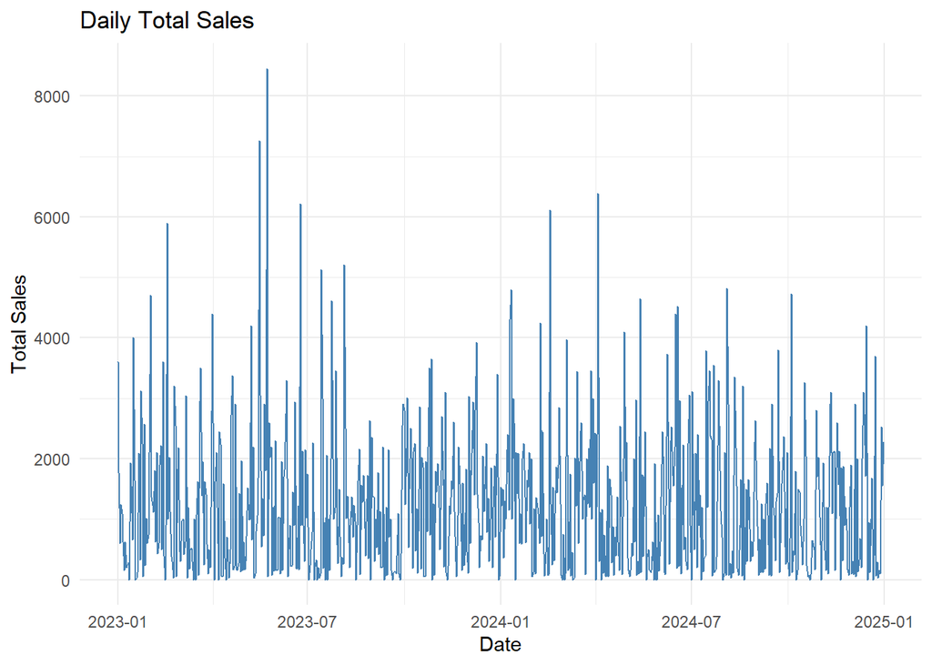

```r
ggplot(daily_sales, aes(x = Date, y = TotalSales)) +
  geom_line(color = "steelblue") +
  labs(title = "Daily Total Sales", x = "Date", y = "Total Sales") +
  theme_minimal()
```

## Decompose the Time Series

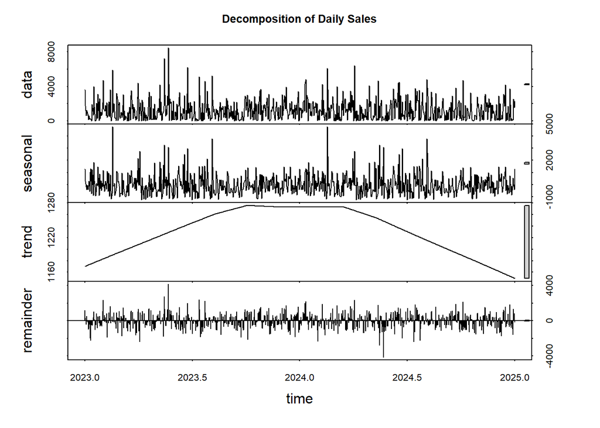

```r
# Decompose using STL (Seasonal-Trend decomposition)
decomp <- stl(sales_ts, s.window = "periodic")

# Plot decomposition
plot(decomp, main = "Decomposition of Daily Sales")
```

stl() decomposes the series using a seasonal window.

The plot shows trend, seasonal cycles, and random noise.

## Check Stationarity

```r
library(tseries)
adf_test <- adf.test(sales_ts, alternative = "stationary")
adf_test
```

```
##
##  Augmented Dickey-Fuller Test
##
## data:  sales_ts
## Dickey-Fuller = -8.2874, Lag order = 9, p-value = 0.01
## alternative hypothesis: stationary
```

Augmented Dickey-Fuller test:

Null hypothesis: series is non-stationary

p-value < 0.05 → series is stationary

Interpretation: If stationary (p < 0.05), we can fit ARIMA/SARIMA directly.

## Holt-Winters Forecast

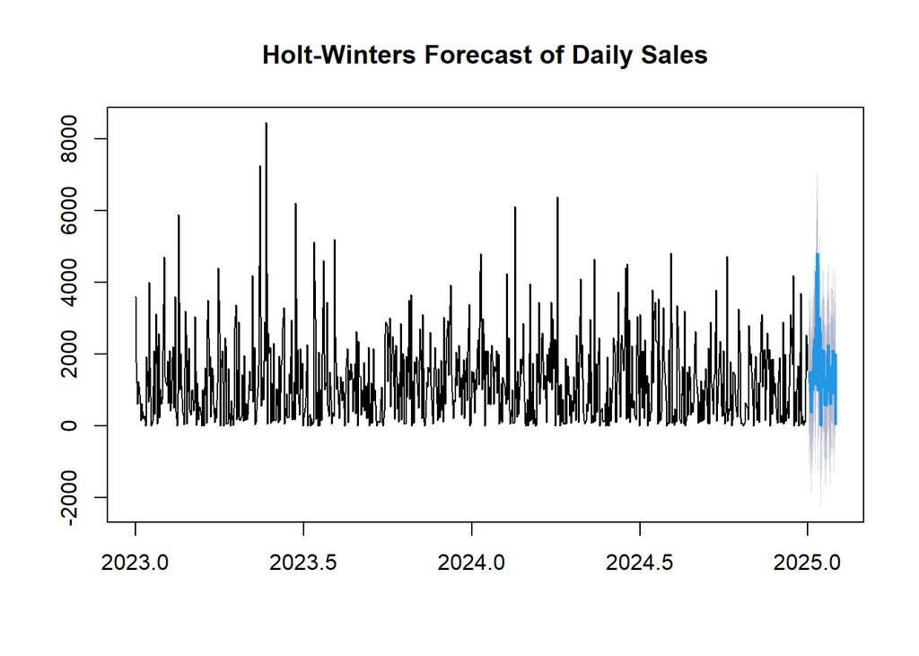

```r
hw_model <- HoltWinters(sales_ts)
hw_forecast <- forecast(hw_model, h = 30)  # forecast next 30 days

# Plot
plot(hw_forecast, main = "Holt-Winters Forecast of Daily Sales")
```

Captures trend and seasonality for short-term forecasting.

## ARIMA Forecast

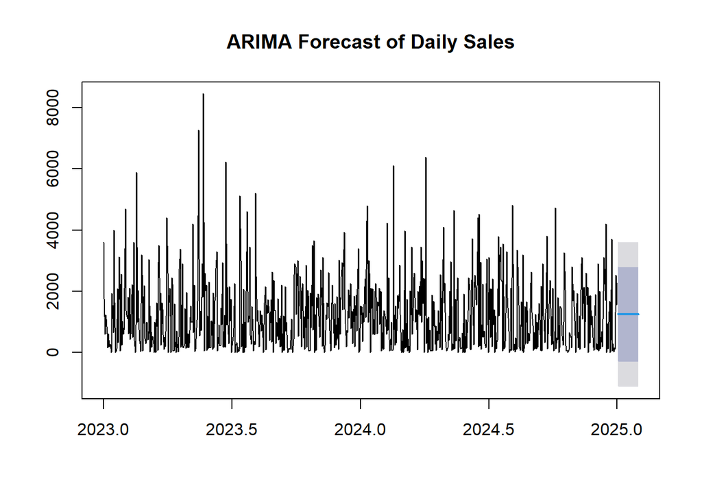

```r
# Automatically select best ARIMA model
arima_model <- auto.arima(sales_ts)
arima_forecast <- forecast(arima_model, h = 30)

# Plot
plot(arima_forecast, main = "ARIMA Forecast of Daily Sales")
```

Automatically selects the best ARIMA model based on AIC.

Handles non-seasonal patterns effectively.

## SARIMA Forecast (Seasonal ARIMA)

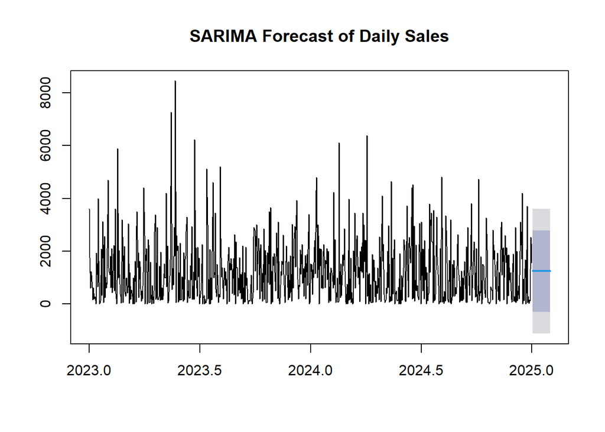

```r
# Use frequency = 365 for yearly seasonality or 7 for weekly
sarima_model <- auto.arima(sales_ts, seasonal = TRUE)
sarima_forecast <- forecast(sarima_model, h = 30)

# Plot
plot(sarima_forecast, main = "SARIMA Forecast of Daily Sales")
```

## Compare Forecasts

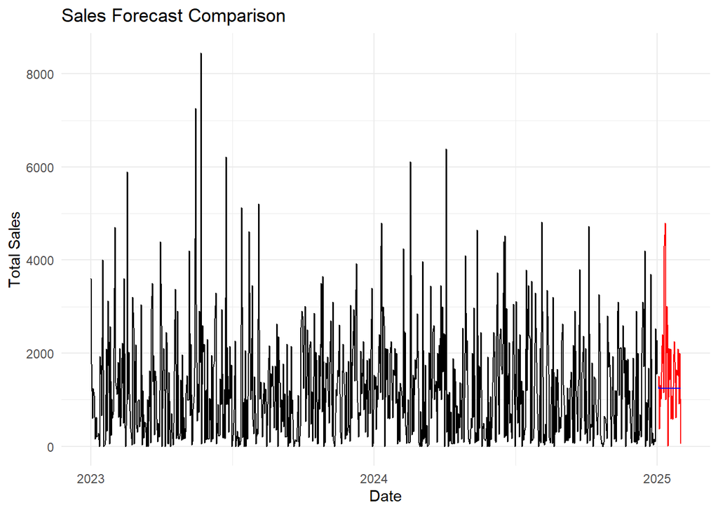

```r
autoplot(sales_ts) +
  autolayer(hw_forecast$mean, series = "Holt-Winters", color = "red") +
  autolayer(arima_forecast$mean, series = "ARIMA", color = "green") +
  autolayer(sarima_forecast$mean, series = "SARIMA", color = "blue") +
  labs(title = "Sales Forecast Comparison", y = "Total Sales", x = "Date") +
  theme_minimal()
```

Overlays all forecasts for easy comparison.

Helps visually check which model best fits the trends and seasonal patterns.

## Quantitative comparison

```r
# Holt-Winters
accuracy(hw_forecast)
```

```
##                     ME     RMSE      MAE MPE MAPE      MASE       ACF1
## Training set -32.85604 1154.081 660.6349 NaN  Inf 0.5009995 0.07042261
```

```r
# ARIMA
accuracy(arima_forecast)
```

```
##                      ME    RMSE      MAE  MPE MAPE      MASE         ACF1
## Training set -0.1037787 1204.46 937.9775 -Inf  Inf 0.7113252 -0.001032686
```

```r
# SARIMA
accuracy(sarima_forecast)
```

```
##                      ME    RMSE      MAE  MPE MAPE      MASE         ACF1
## Training set -0.1037787 1204.46 937.9775 -Inf  Inf 0.7113252 -0.001032686
```

Interpretation

1. RMSE (Root Mean Squared Error): Lower is better.
- Holt-Winters (1154) < ARIMA/SARIMA (1204), so Holt-Winters fits slightly better on the training set.
2. MAE (Mean Absolute Error): Lower is better.
- Holt-Winters (660) < ARIMA/SARIMA (938) → again, Holt-Winters is better.
3. MAPE (Mean Absolute Percentage Error): Inf
- This happens because some daily sales values are 0, causing division by zero. It’s common in sparse retail data.
- Ignore MAPE here and focus on RMSE/MAE.
4. ME (Mean Error):
- Holt-Winters has a slightly larger negative bias (-32), ARIMA/SARIMA almost 0.
5. ACF1 (lag-1 autocorrelation of residuals):
- Holt-Winters: 0.07 (small autocorrelation, acceptable)
- ARIMA/SARIMA: ~0 (residuals uncorrelated, good)

Conclusion

- Based on RMSE and MAE, Holt-Winters performs best on your training set.
- ARIMA and SARIMA are very close and slightly worse.